# ITQ Corollaries

Ernesto Carrella

October 14, 2015

## ITQ and gear changes

One important result in Miller’s paper on ITQs in California is that it incentivates gear switching. Here I show that this result can be replicated into our model.

There are two kinds of fish, red and blue. They are perfectly mixed throughout the map at a ratio of 70 red to 30 blue. Both blue and red fish are valuable (10$ a unit). Each fisher is given 4500 red quotas a year and only 500 blue ones.  
Blue quotas are rare enough that their prices rise above their sale price. It is therefore unprofitable to fish blue.

Each fisher is given a gear that has a separate catchability value for red and blue fishes, both initially $\sim U[0.001,0.02]$.  
At the end of each year, each fisher has a 20% chance of randomly get a new gear and a 60% chance of comparing yearly profits with a friend and copy that person’s gear if they were more succesful.  
Very quickly agents converge to gear that catch a lot of red and very little blue:

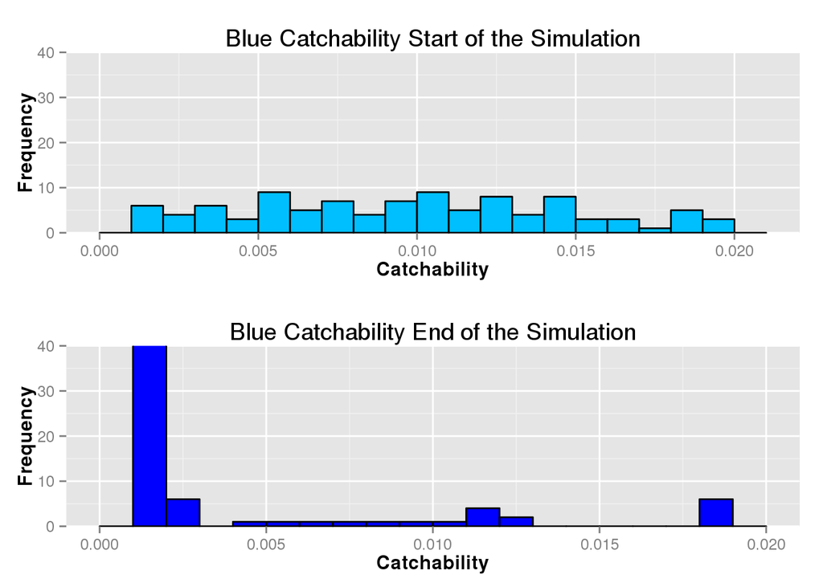

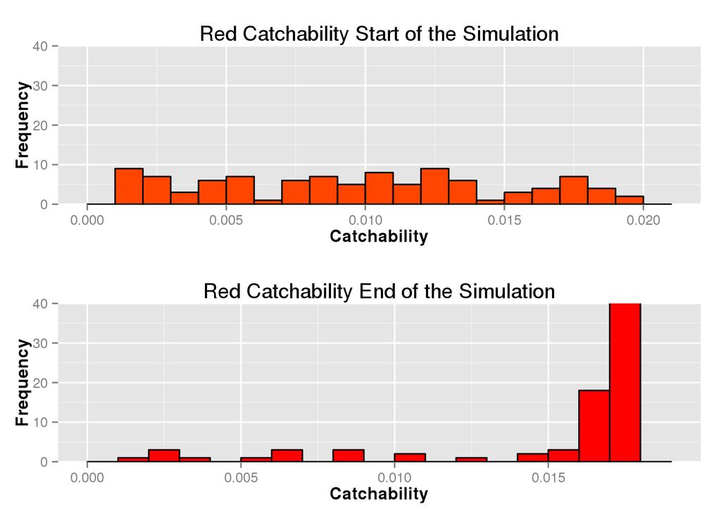

The results are quite efficient too in the sense that while at the beginning of the simulation the blue quotas limited how many reds could be caught, after 10 years it is the red quotas (the profitable one) that becomes binding. You can see this in the next graph (the dashed lines represent the yearly quotas allowed and therefore the maximum landing per specie).

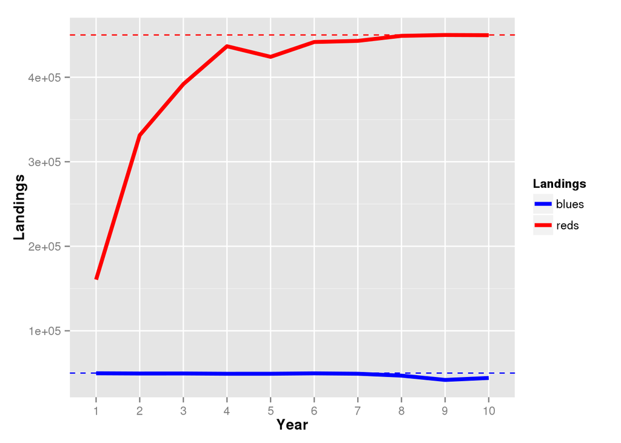

## ITQ and geographical change

When we got to interview Miller in Santa Barbara I did ask him why wouldn’t the policymakers just put a fine on protected species rather than going through the whole pain of instituting ITQs. He said that, in a way, setting up quotas is just like levying fines but where the policymakers just set the biological target and the monetary value emerges from the fishermen.

In a way then, ITQs should produce results [similar to setting up fines](http://carrknight.github.io/poseidon/bycatch/bycatch.html).  
In this scenario then I have the world geographically separated. In the north only Red fish live. In the south blue and reds occur on a 1:1 ratio. Blue quotas are again much scarcer: each fisher is given 4500 red quotas a year and 500 blue ones. This should create an incentive for fishers to tow north rather than south.

[video not shown]

The idea turns out to be true, the number of tows is much larger on the north side of the map than on the south side. What is interesting though is that there is a lot of variation year to year:

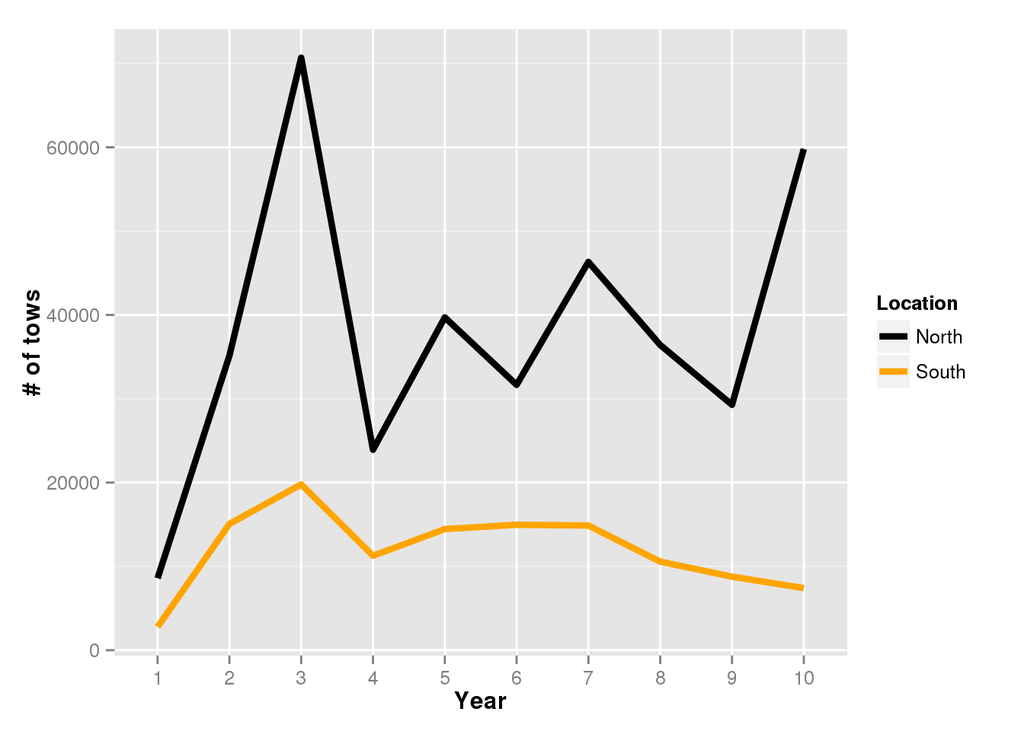

The reason might be easier to understand graphically: as agents fish north more than south they consume areas close to port. Also, the more people go north the cheaper the quotas for the blue fish become. At some point it must become more profitable to buy quotas and fish south instead.  
In the video you can see that the overfished areas are predominantly north.

[video not shown]